# Hábitos de sueño, bebidas energéticas y bienestar estudiantil

Piero Max Ortiz Villafuerte (Líder)

Joel Modesto Cayllahua Hilario

Salvador Donayre Epifania

Sebastian Ernesto Chahuara Galdos

Marisol Yaranga Delgado

## Antecedentes

**Relevancia**: El estilo de vida de los estudiantes universitarios y de institutos se encuentra estrechamente relacionado con factores que afectan su salud física y mental como el consumo de bebidas energéticas, la cual aumenta consirablemente por las exigencias académicas, provocando alteraciones en los hábitos de sueño y afectando el bienestar estudiantil.

**Justificación**: El análisis de la relación entre el consumo de bebidas energéticas y el bienestar estudiantil es relevante para identificar patrones que permitan orientar estrategias de salud en la comunidad académica.

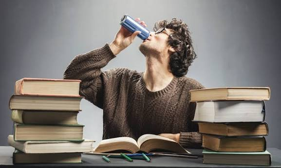

## Objetivos

**Objetivo general**:

- Analizar la relación entre el consumo de bebidas energéticas y los hábitos de sueño, actividad física y bienestar general de estudiantes universitarios y de institutos durante el ciclo académico 2026-I mediante herramientas de análisis estadístico y probabilístico.

**Objetivos específicos**

- Determinar la relación entre la frecuencia de consumo de bebidas energéticas y las horas de sueño diarias de los estudiantes durante el ciclo académico 2026-I.
- Analizar la relación entre el nivel de estrés autopercibido y la calidad de sueño reportada por los estudiantes durante el ciclo académico 2026-I.

## Datos y Limpieza de Datos

- Datos obtenidos mediante una encuesta hacia estudiantes universitarios y de institutos.
- Muestreo no probabilístico por conveniencia
- Limpieza: validación de rangos (ej. Edad ∈ [17,25], HorasSuenio ∈ [3,12]), normalización de categorías textuales, eliminación de registros sin edad, sexo o carrera.
- Variables renombradas de preguntas largas a nombres cortos.

## Variables

| Variable | Tipo | Restricción |
| --- | --- | --- |
| Edad | Cuantitativa discreta | [17, 25] años |
| Sexo | Cualitativa nominal | Masculino / Femenino |
| HorasSuenio | Cuantitativa continua | [3, 12] horas |
| HorasEjercicio | Cuantitativa continua | [0, 20] horas |
| FrecBebida | Cuantitativa discreta | [0, 7] días/semana |
| UnidadBebida | Cuantitativa discreta | [0, 5] unidades/día |
| CalidadSuenio | Cualitativa ordinal | Muy mala → Muy buena |
| Estres | Cualitativa ordinal | Nulo → Muy alto |
| ActividadFisica | Cualitativa nominal | 5 categorías |
| Carrera | Cualitativa nominal | 6 áreas |
| CantidadCursos | Cuantitativa discreta | [3, 8] cursos |
| CicloAcademico | Cualitativa ordinal | [1, 10] |
| CanDesayuno | Cualitativa ordinal | Ninguna → Mucha |

## Análisis Univariado

[figure not shown]

Fig 1. FrecBebida (días/semana)

[figure not shown]

Fig 3. CalidadSuenio

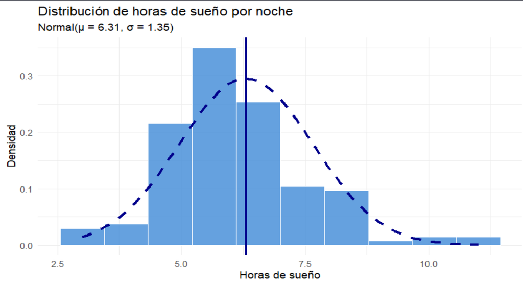

Fig 2. HorasSuenio (horas/noche)

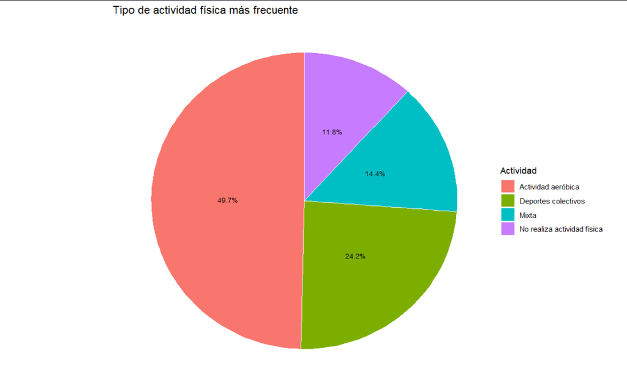

Fig 4. ActividadFisica

## Análisis Bivariado

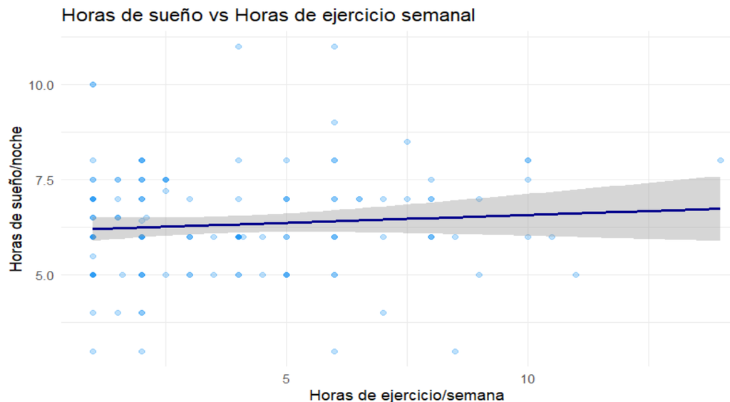

Fig 1. HorasSuenio vs HorasEjercicio (num-num)

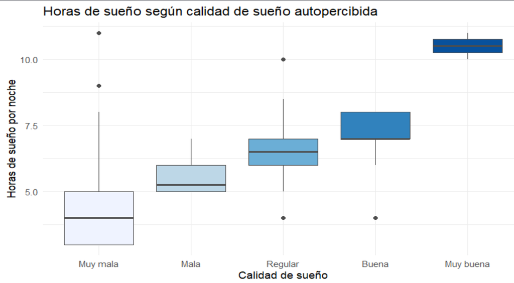

Fig 3. CalidadSuenio vs HorasSuenio (cat-num)

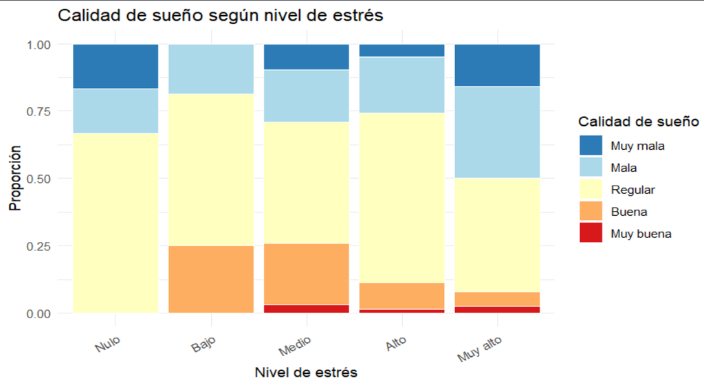

Fig 2. CalidadSuenio vs Estres (cat-cat)

## Probabilidad Empírica

**Variable 1 — FrecBebida**

$EA_1$: seleccionar una persona al azar y observar cuántos días por semana consume bebidas energéticas.

$$\Omega_{EA_1} = \{0,1,2,3,4,5,6,7\}$$

| Días/semana | Frecuencia | P(Eᵢ) |
| --- | --- | --- |
| 0 | 621 | 0.5210 |
| 1 | 178 | 0.1493 |
| 2 | 151 | 0.1267 |
| 3 | 91 | 0.0763 |
| 4 | 63 | 0.0529 |
| 5 | 57 | 0.0478 |
| 6 | 14 | 0.0117 |
| 7 | 17 | 0.0143 |

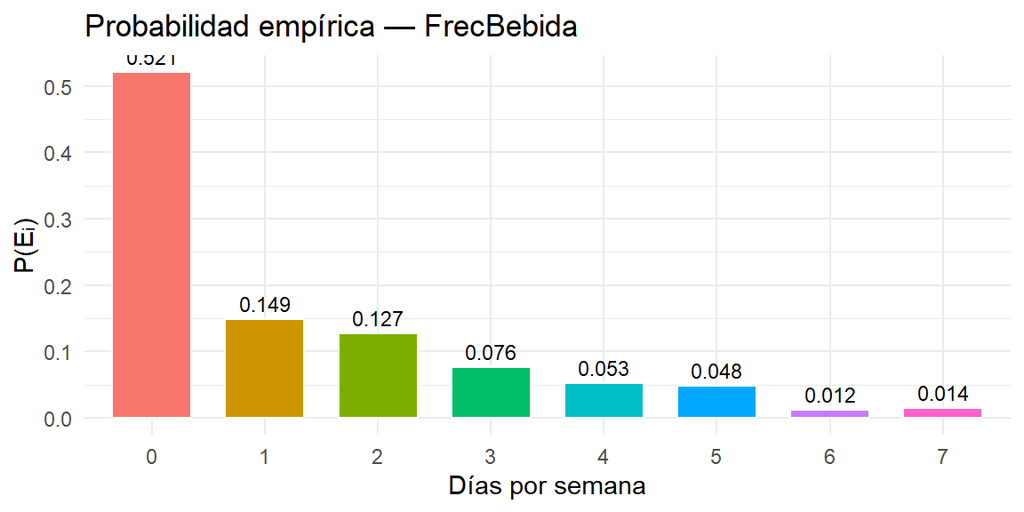

```
P(0 días) = 0.521 | P(7 días) = 0.0143 | Suma = 1
```

**Variable 2 — CalidadSuenio**

$EA_2$: seleccionar una persona al azar y observar su calidad de sueño autopercibida.

$$\Omega_{EA_2} = \{\text{Muy mala},\ \text{Mala},\ \text{Regular},\ \text{Buena},\ \text{Muy buena}\}$$

| Categoría | Frecuencia | P(Eᵢ) |
| --- | --- | --- |
| Muy mala | 70 | 0.0587 |
| Mala | 247 | 0.2072 |
| Regular | 577 | 0.4841 |
| Buena | 239 | 0.2005 |
| Muy buena | 59 | 0.0495 |

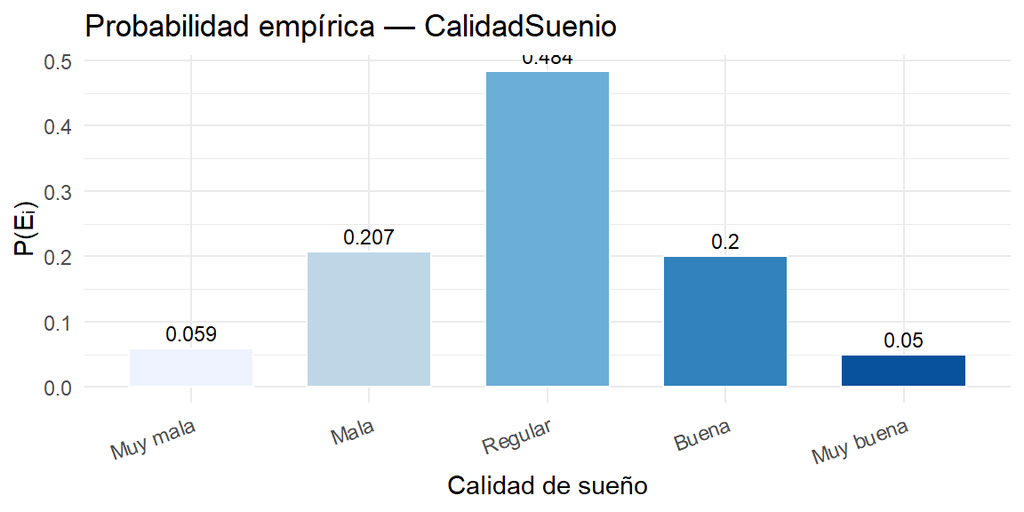

```
P(Regular) = 0.4841 | P(Mala o Muy mala) = 0.2659
```

→ Regular concentra **≈48.4%** de las observaciones. Sueño deficiente (Mala o Muy mala) = **0.266**.

## Probabilidad Condicional

**Eventos:** $E_1$ = no consume bebidas energéticas (FrecBebida = 0) · $E_2$ = sueño **Regular, Mala o Muy mala**

**Definición formal de independencia:** dos eventos $A$ y $B$ son independientes si y solo si
$$P(A \cap B) = P(A) \cdot P(B)$$
De lo contrario, son **dependientes**.

```
P(E1) = 0.521 | P(E2) = 0.75
```

```
P(E1 ∩ E2) = 0.3935 | P(E1)·P(E2) = 0.3907
```

```
P(E1|E2) = 0.5246 | P(E2|E1) = 0.7552
```

```
Los eventos son DEPENDIENTES
```

```
T. Bayes P(E2|E1) = 0.7552
```

```
 ✓ Verificado
```

**Conclusión:** como $P(E_1 \cap E_2) = 0.3935 \neq P(E_1)\cdot P(E_2) = 0.3907$, los eventos son **DEPENDIENTES**. El **75.5%** de quienes no consumen reporta sueño Regular o peor, ligeramente superior a la marginal 75%. Evitar el consumo no garantiza mejor sueño — otros factores como el estrés influyen más. Bayes verifica el resultado ✓.

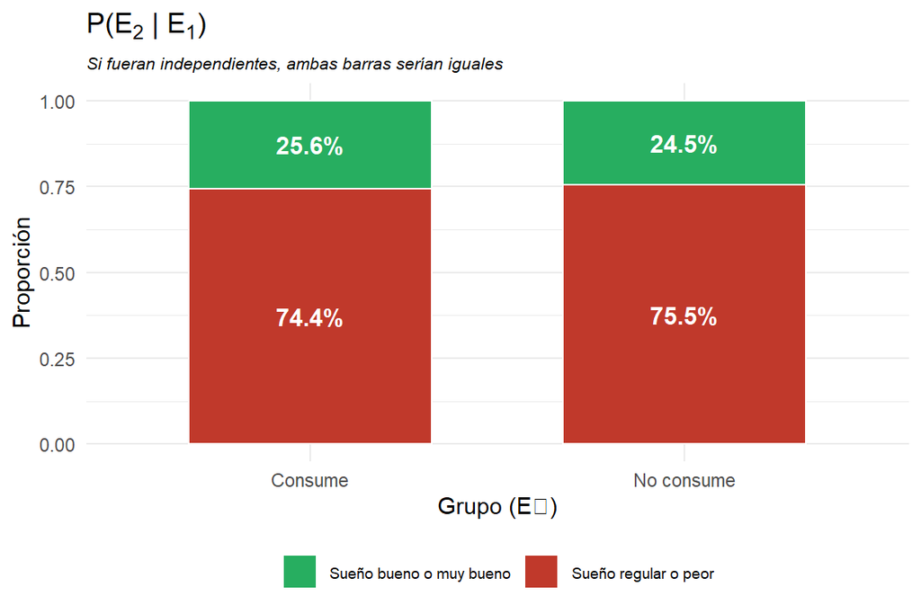

## Variables Aleatorias Discretas

**Geométrica — FrecBebida**

$$X \sim \text{Geom}(p) \quad ; \quad P(X=k) = (1-p)^{k-1}\,p$$

Nº de estudiantes seleccionados hasta el primer consumidor.

**¿Por qué Geom?**

- Cada estudiante es un ensayo independiente con dos resultados (consume / no consume).
- Probabilidad $p$ constante en cada ensayo.
- Se cuenta el nº de ensayos hasta el **primer éxito**.
- Soporte: $X \in \{1, 2, 3, \ldots\}$ (no acotado).

```
p = 0.479
```

```
E(X) = 2.0876 | V(X) = 2.2704 | SD(X) = 1.5068
```

```
P(X=3) = 0.13 | P(X≤5) = 0.9616
```

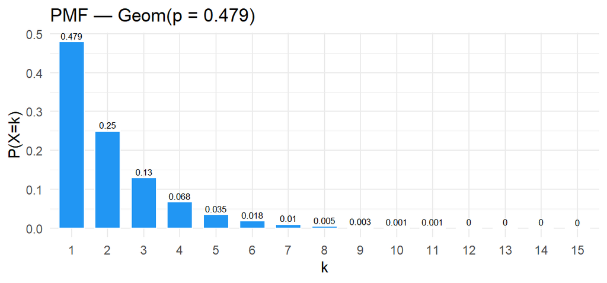

→ Bastan **2.1 estudiantes** en promedio; en el 96% de casos aparece dentro de 5 intentos.

**Binomial — CalidadSuenio**

$$Y \sim \text{Bin}(n,p) \quad ; \quad P(Y=k) = \binom{n}{k} p^k (1-p)^{n-k}$$

Nº con sueño deficiente en un grupo de $n=10$ estudiantes.

**¿Por qué Binomial?**

- Nº fijo de ensayos: $n = 10$ estudiantes.
- Cada ensayo es éxito/fracaso (sueño deficiente / no deficiente).
- Probabilidad $p$ constante (mismo nivel de la encuesta).
- Ensayos asumidos independientes.
- Soporte: $Y \in \{0, 1, 2, \ldots, 10\}$ (acotado por $n$).

```
p = 0.2659
```

```
E(Y) = 2.6594 | V(Y) = 1.9522 | SD(Y) = 1.3972
```

```
P(Y=2) = 0.2683 | P(Y≤3) = 0.7375
```

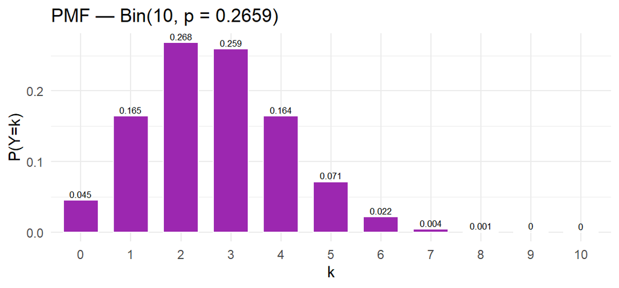

→ Se esperan **2.66 estudiantes** deficientes por grupo de 10; en el 74% de grupos habrá a lo mucho 3.

## Variables Aleatorias Continuas

**Exponencial — HorasEjercicio**

$$Z \sim \text{Exp}(\lambda) \quad ; \quad f(z) = \lambda e^{-\lambda z}$$

**¿Por qué Exponencial?**

- Variable continua positiva ($Z \geq 0$).
- Asimetría = **1.63** (cola derecha pronunciada).
- Curtosis = **6.24**, incompatible con Normal.
- Media ≈ SD, propio de Exp ($E(Z) = SD(Z) = 1/\lambda$).
- Soporte: $Z \in [0, \infty)$.

```
n = 1186 | Media = 3.6793 | SD = 2.9931
λ = 0.2718 | E(Z) = 1/λ = 3.6793 | V(Z) = 1/λ² = 13.5369
```

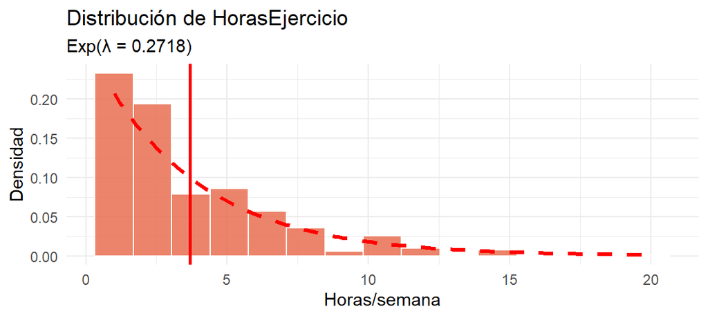

```
P(Z > 5) = 0.2569 → 25.7 % > 5 hrs/semana
```

→ **74.3%** realiza 5 hrs o menos.

**Normal — HorasSuenio**

$$W \sim N(\mu, \sigma^2) \quad ; \quad f(w) = \tfrac{1}{\sigma\sqrt{2\pi}} e^{-\tfrac{(w-\mu)^2}{2\sigma^2}}$$

**¿Por qué Normal?**

- Variable continua simétrica alrededor de su media.
- Asimetría = **0.26** (≈ 0, simétrica).
- Curtosis = **3.57** (≈ 3, mesocúrtica).
- Histograma con forma de campana centrada en μ.
- Soporte: $W \in (-\infty, \infty)$ (en práctica acotado por la fisiología).

```
n = 1172 | μ = 6.3444 | σ = 1.3698
E(W) = μ = 6.3444 | V(W) = σ² = 1.8764
```

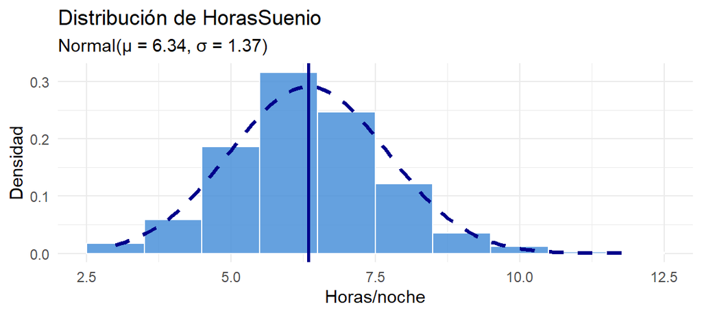

```
P(6 ≤ W ≤ 8) = 0.4859 → 48.6 % duerme 6-8 hrs
```

→ **48.6%** duerme en el rango recomendado (6-8 hrs).